# Steps for Visualing Data

Vanuatu National Statistics Office

15 Jul 2020

## 0.1 Introduction

The world today is filled with data and it becomes imperative that we analyse it properly to gain meaningful insights. Data Visualisation is a vital tool that can unearth possible crucial insights from data. If the results of an analysis are not visualised properly, it will not be communicated effectively to the desired audience. In this tutorial, we will learn how to analyze and display data using R statistical language. R is extremely flexible and easy to use when it comes to creating visualisations.

We’ll be using the `carInfo-Prices_27-05-20.csv` dataframe, this is the dataset that we cleaned and processed in the previous tutorial. The current tutorial was created using Rmarkdown - a powerful tool to help us create formatted using R code. If you’re interested in using Rmarkdown, there is a great tutorial [here](https://rmarkdown.rstudio.com/lesson-1.html).

## 0.2 Setting the working directory

Next, we’ll set the working directory - usually the folder on our computer where we have stored our data. We can use the following code for this:

```r
# Note the name of our working directory
workingDirectory <- file.path("insert", "path", "to", "working", "directory", "here")

# Set the working directory
setwd(workingDirectory)
```

## 0.3 Loading required libraries

The power of R is that millions of people are using it. R comes with a large set of `base` functions that we’ll be using. Sometimes though it is useful to use some additional libraries. We can install and load libraries with the following code to visualise our data:

```r
install.packages("dplyr") # We'll use this package to manipulate and analyse our data
install.packages("ggplot2") # We'll use this package to visualise our data
```

Once installed, load them with the following code:

```r
# Load the libraries
library(dplyr)
library(ggplot2)
```

## 0.4 Importing the data

With our working directory set, we can now import some data. Today our data will be in `csv` (**C**omma, **S**eparated **V**alues) format, which is a standard format for storing a table in a simple text form.

Here is some code to read in a csv file:

```r
completeMotorCarTrends <- read.csv(file.path("..", "data", "carInfo-Prices_27-05-20.csv"), header= TRUE)
```

## 0.5 Visualising the Data

### 0.5.1 Ordered Bar Chart

Ordered Bar Chart is a Bar Chart that is ordered by the Y axis variable. Just sorting the dataframe by the variable of interest isn’t enough to order the bar chart. In order for the bar chart to retain the order of the rows, the X axis variable (i.e. the categories) has to be converted into a factor.

What Car Model consumes the least fuel?

```r
#Prepare data
milesPerGallonCars<- completeMotorCarTrends %>% group_by(CarModel) %>%
  summarise(mean= mean(MilesPerGallon))

newColumnNames <- c("Car Model","Av. Miles per Gallon")
colnames(milesPerGallonCars) <- newColumnNames
head(milesPerGallonCars)
```

```
## # A tibble: 6 x 2
##   `Car Model` `Av. Miles per Gallon`
##   <chr>                        <dbl>
## 1 "Cadillac "                   11.8
## 2 "Datsun "                     22.8
## 3 "Ferrari"                     19.7
## 4 "Fiat"                        27.3
## 5 "Fiat "                       32.4
## 6 "Ford "                       15.8
```

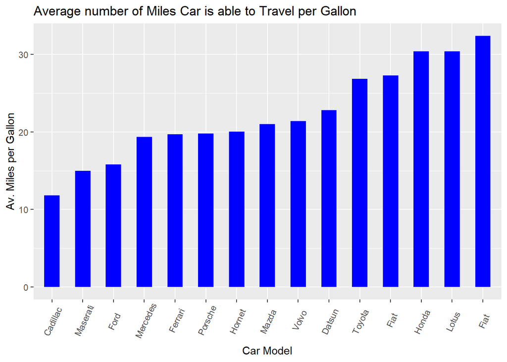

```r
milesPerGallonCars<- milesPerGallonCars[order(milesPerGallonCars$`Av. Miles per Gallon`), ] #sort
milesPerGallonCars$`Car Model`<- factor(milesPerGallonCars$`Car Model`, levels = milesPerGallonCars$`Car Model`) #retain order in plot

#Plot
ggplot(milesPerGallonCars, aes(x=`Car Model`, y=`Av. Miles per Gallon`)) +
  geom_bar(stat="identity", width=.5, fill="blue") + labs(title="Average number of Miles Car is able to Travel per Gallon") +
  theme(axis.text.x = element_text(angle=65, vjust=0.6))
```

### 0.5.2 Horizontal Bar Chart

Horizontal bar chart is a slight variation on the vertical bar chart, with the primary difference being the inverted positions of the x-axis and y-axis. To invert the positions of the x and y axis, add the ‘coord_flip()’ function. The Ordered Bar Chart above has been made into a horizontal bar chart below.

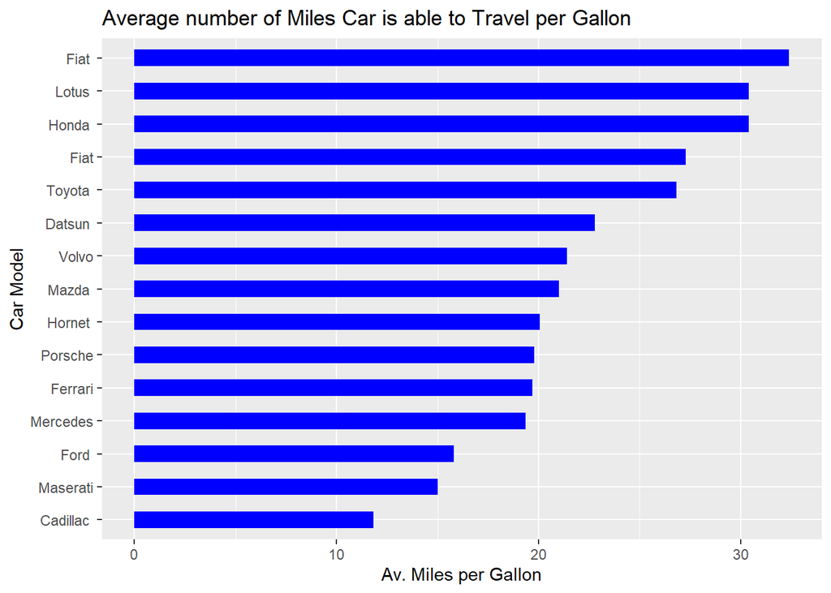

```r
#Create horizontal bar chart
ggplot(milesPerGallonCars, aes(x=`Car Model`, y=`Av. Miles per Gallon`)) +
  geom_bar(stat="identity", width=.5, fill="blue") + labs(title="Average number of Miles Car is able to Travel per Gallon") + coord_flip()
```

### 0.5.3 Grouped Bar Chart

Grouped bar charts are used when two or more data sets are displayed side-by-side and grouped together under categories on the same axis. It is essentially a simple bar chart with two or more graphs.

Are men spending more on vehicles then women?

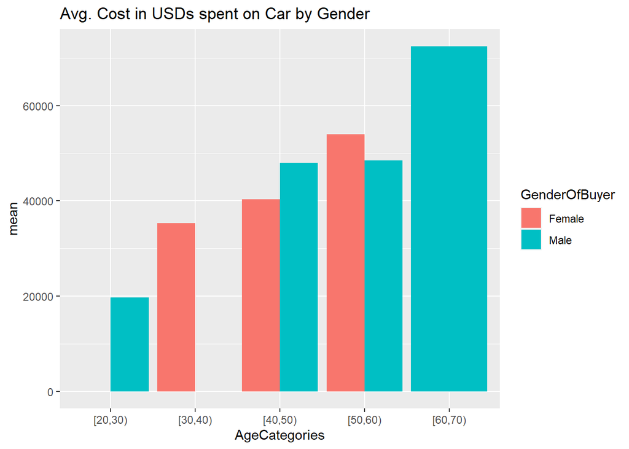

```r
#Prepare data
costOfCarMeans<- completeMotorCarTrends %>% group_by(GenderOfBuyer, AgeCategories) %>%
  summarise(mean= mean(CostOfCar))

#Plot
ggplot(costOfCarMeans, aes(x=AgeCategories , y=mean, fill=GenderOfBuyer)) +
  geom_bar(stat= "identity", position= "dodge") +
  labs(title="Avg. Cost in USDs spent on Car by Gender")
```

### 0.5.4 Lollipop Chart

Lollipop charts conveys the same information as in bar charts. By reducing the thick bars into thin lines, it reduces the clutter and lays more emphasis on the value. It looks nice and modern.

Do citizens spend more on their vehicles as they advance in years?

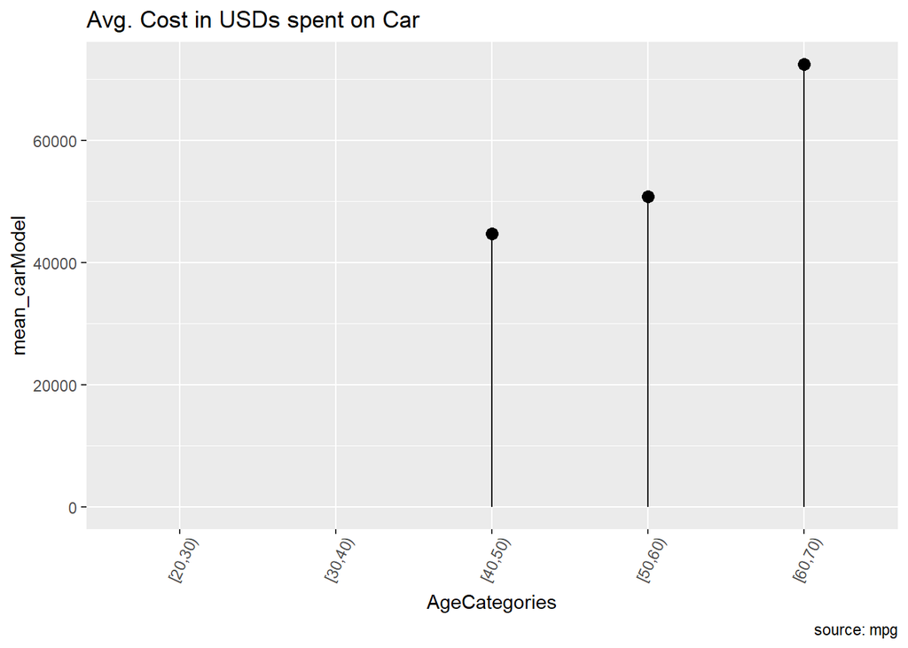

```r
#Prepare data
groupedCompleteMotorCarTrends<- group_by(completeMotorCarTrends, AgeCategories)
summariseCompleteMotorCarTrends<- summarise(groupedCompleteMotorCarTrends, mean_carModel= mean(CostOfCar))

# Plot
ggplot(summariseCompleteMotorCarTrends, aes(x=AgeCategories, y=mean_carModel)) +
  geom_point(size=3) + geom_segment(aes(x=AgeCategories,
                                        xend=AgeCategories,
                                        y=0,
                                        yend=mean_carModel)) +
  labs(title="Avg. Cost in USDs spent on Car", caption="source: mpg") +
  theme(axis.text.x = element_text(angle=65, vjust= 0.6))
```

### 0.5.5 Boxplot

Box plot is an excellent tool to study the distribution. It can also show the distributions within multiple groups, along with the median, range and outliers if any. The dark line inside the box represents the median. The top of box is 75%ile and bottom of box is 25%ile. The end points of the lines (aka whiskers) is at a distance of 1.5*IQR, where IQR or Inter Quartile Range is the distance between 25th and 75th percentiles. The points outside the whiskers are marked as dots and are normally considered as extreme points.

Is the cost of fuel for car models distributed evenly?

```r
# Calculate the cost per mile
completeMotorCarTrends$CostPerMile <- 1/completeMotorCarTrends$MilesPerUSD

#Prepare the data
costPerMileBoxPlot <- completeMotorCarTrends[ , c("CarModel", "CostPerMile")]
head(costPerMileBoxPlot)
```

```
##   CarModel CostPerMile
## 1   Mazda    0.4761905
## 2   Mazda    0.4761905
## 3  Datsun    0.4385965
## 4  Hornet    0.4672897
## 5  Hornet    0.5347594
## 6    Ford    0.5524862
```

```r
colClasses <- sapply(costPerMileBoxPlot, FUN=class)
print(colClasses)
```

```
##    CarModel CostPerMile
## "character"   "numeric"
```

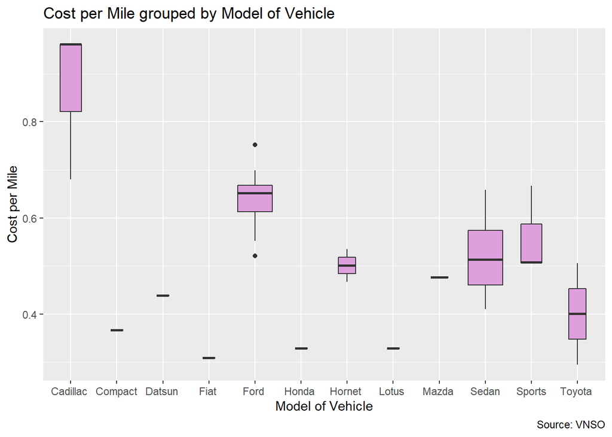

```r
# Create dataset of vehicle types
Sedan <- c("Cadillac", "Mercedes", "Hornet", "Mazda", "Datsun", "Toyota", "Volvo")
Sports <- c("Maserati", "Porsche", "Ferrari", "Lotus")
Pickup<- c("Ford")
Compact<- c("Fiat", "Fiat", "Honda")

costPerMileBoxPlot$CarModel[costPerMileBoxPlot$CarModel %in% Sedan] <- "Sedan"
costPerMileBoxPlot$CarModel[costPerMileBoxPlot$CarModel %in% Sports] <- "Sports"
costPerMileBoxPlot$CarModel[costPerMileBoxPlot$CarModel %in% Pickup] <- "Pickup"
costPerMileBoxPlot$CarModel[costPerMileBoxPlot$CarModel %in% Compact] <- "Compact"

# Plot
Plot<- ggplot(costPerMileBoxPlot, aes(CarModel, CostPerMile))
Plot + geom_boxplot(varwidth = TRUE, fill= "plum") +
  labs(title= "Cost per Mile grouped by Model of Vehicle",
       caption= "Source: VNSO",
       x= "Model of Vehicle",
       y= "Cost per Mile")
```

### 0.5.6 Scatter Plot

Scatter plot is a graph in which values of two variables are plotted along two axes, the pattern of the resulting points reveals if any correlation is present (relationship between two variables). It is the most frequently used plot for data analysis.

Is there a relationship between horsepower and the time it takes to travel a quarter of a mile?

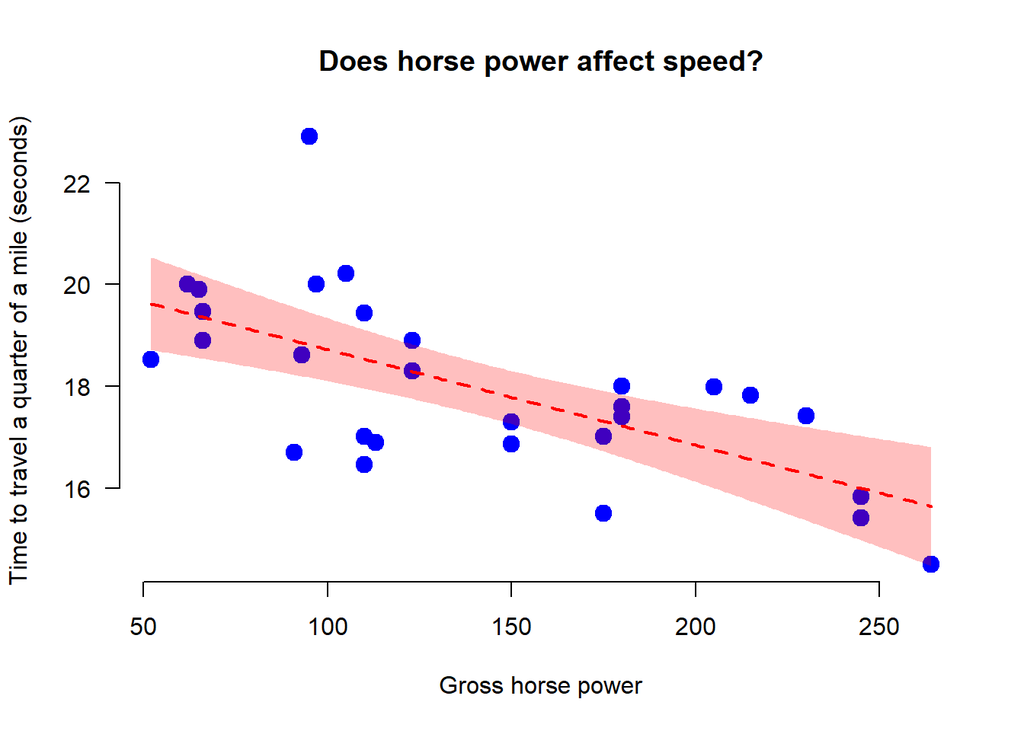

```r
plot(x=completeMotorCarTrends$HorsePower, y=completeMotorCarTrends$TimeToQuarterMile,
     bty="n", # Remove box from around plot
     pch=19, # Set the plotting shape
     las=1, # Set the angle of tick labels to be horizontal
     main="Does horse power affect speed?", # Add a plot title
     ylab="Time to travel a quarter of a mile (seconds)", # Y axis label
     xlab="Gross horse power", # X axis label
     col="blue", # Set colour of points
     cex=1.5) # Set the size of the points

# Run a simple linear regression to test whether there is a relationship
linearModelResults <- lm(TimeToQuarterMile ~ HorsePower, data=completeMotorCarTrends)

# Replace NA from the column HorsePower with the Mean HorsePower]

completeMotorCarTrends$HorsePower[is.na(completeMotorCarTrends$HorsePower)] = 147

# Generate some example horse power values - for predicting speed
horsePowerValues <- seq(min(completeMotorCarTrends$HorsePower), max(completeMotorCarTrends$HorsePower), by=1)

# Predict the time taken to travel a quarter mile for the example values
confidenceIntervals <- predict(linearModelResults, newdata=data.frame(HorsePower=horsePowerValues),
                               interval="confidence", # Record the confidence intervals around predicted values
                               level=0.95) # Set the level for the confidence intervals

# Add the confidence intervals onto the plot as a polygon
polygon(x=c(horsePowerValues, rev(horsePowerValues)),
        y=c(confidenceIntervals[, 2], rev(confidenceIntervals[,3])),
        col=rgb(1,0,0, 0.25), # Set the colour to be red and slightly transparent
        border=NA) # Remove the border from around the polygon

# Add a line of best fit to the plot
lines(x=horsePowerValues,
      y=confidenceIntervals[, 1],
      col="red", # Set the line colour to be red
      lty=2, # Set the type of the line to be dashed
      lwd=2) # Set the width of the line
```

Here is how we could produce a similar linear regression plot using ggplot code:

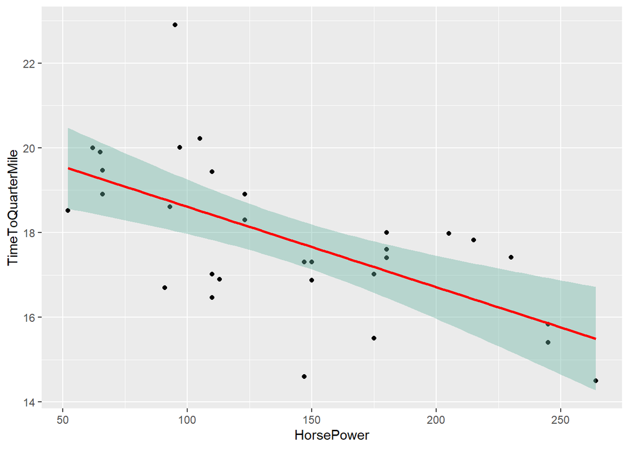

```r
ggplot(completeMotorCarTrends, aes(x=HorsePower, y=TimeToQuarterMile)) +
  geom_point() +
  geom_smooth(method=lm , color="red", fill="#69b3a2", se=TRUE)
```